# NSynth Dataset

### Mel Spectrogram [librosa.feature.melspectrogram](https://librosa.github.io/librosa/generated/librosa.feature.melspectrogram.html)

The **spectrogram** is a basic tool in audio spectral analysis and other fields. It has been applied extensively in speech analysis. The spectrogram can be defined as an intensity plot (usually on a log scale, such as dB) of the Short-Time Fourier Transform (STFT) magnitude. The STFT is simply a sequence of Fast Fourier Transforms (FFT) of windowed data segments, where the windows are usually allowed to overlap in time, typically by 25-50%. It is an important representation of audio data because human hearing is based on a kind of real-time spectrogram encoded by the cochlea of the inner ear.  
The spectrogram has been used extensively in the field of computer music as a guide during the development of sound synthesis algorithms. When working with an appropriate synthesis model, matching the spectrogram often corresponds to matching the sound extremely well. In fact, spectral modeling synthesis (SMS) is based on synthesizing the short-time spectrum directly by some means.

The **mel** is a unit of pitch. The mel scale is a scale of pitches judged by listeners to be equal in distance one from another.

Sources:  
[Spectrograms](https://ccrma.stanford.edu/~jos/st/Spectrograms.html)  
[Stevens, Stanley Smith; Volkmann; John & Newman, Edwin B. (1937). "A scale for the measurement of the psychological magnitude pitch"](https://archive.is/20130414065947/http://asadl.org/jasa/resource/1/jasman/v8/i3/p185_s1)

```python
spectrograms_mel = []

for y_, sr_ in zip(y, sr):
    # Passing through arguments to the Mel filters
    spectrograms_mel.append(librosa.feature.melspectrogram(y=y_, sr=sr_, n_mels=128,fmax=8000))
```

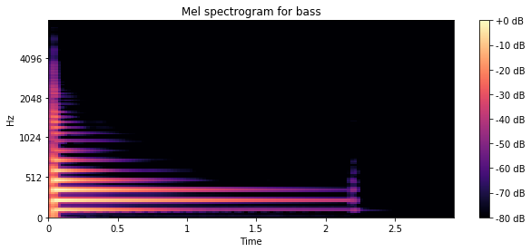

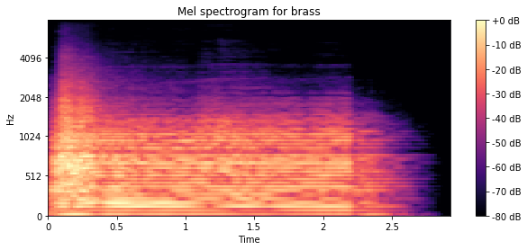

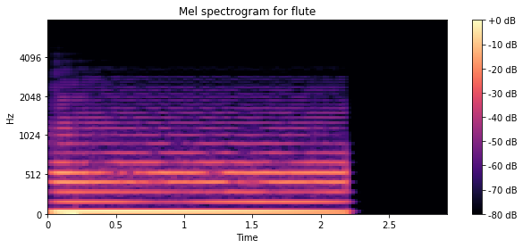

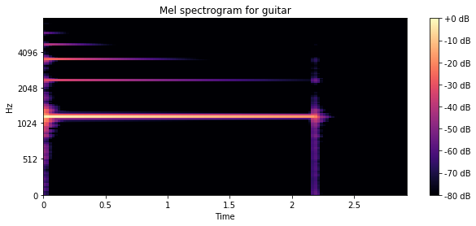

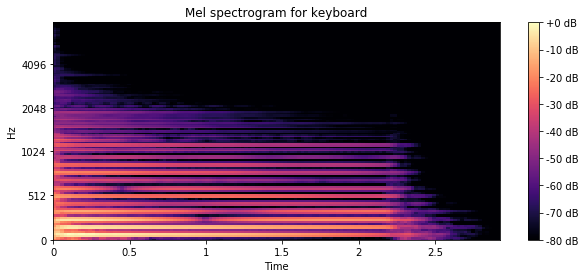

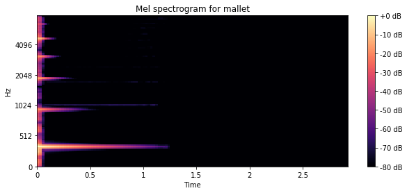

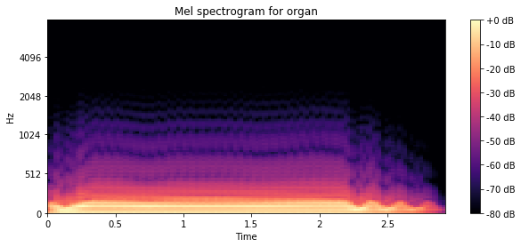

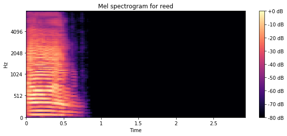

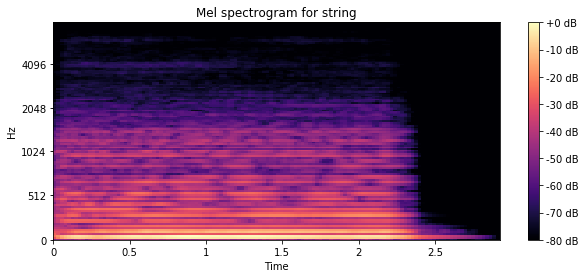

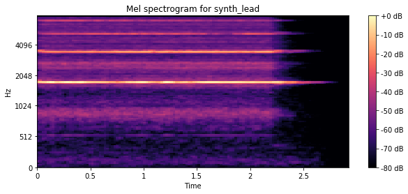

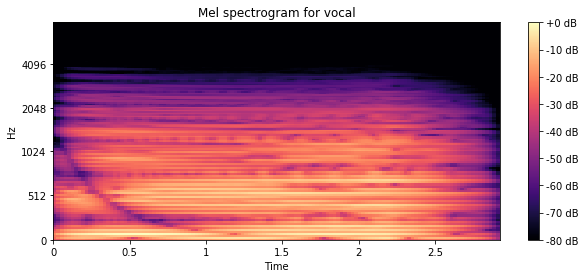

```python
for S, instrument, i in zip(spectrograms_mel,class_names, range(len(class_names))):
    plt.figure(figsize=(10,4))
    librosa.display.specshow(librosa.power_to_db(S,ref=np.max),
                         y_axis='mel', fmax=8000, x_axis='time')
    plt.colorbar(format='%+2.0f dB')
    plt.title("Mel spectrogram for " + instrument)
    plt.savefig('plots/mel_spectro_'+str(class_names[i])+'.png')

plt.show()
```

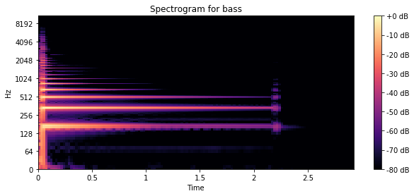

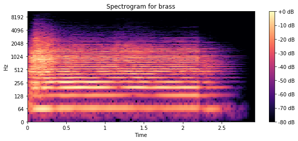

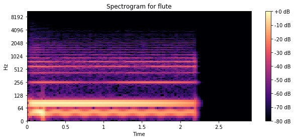

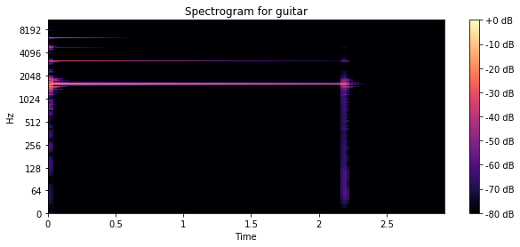

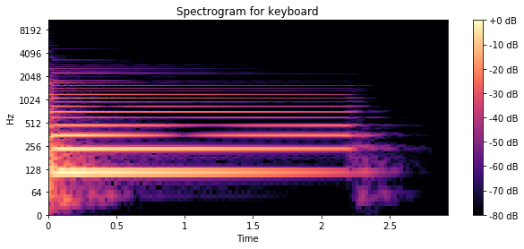

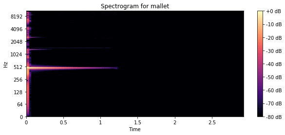

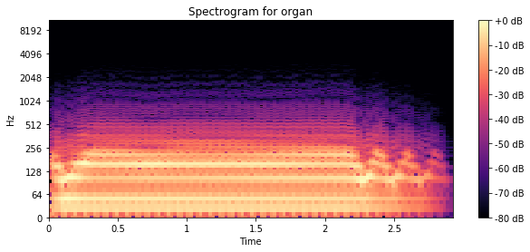

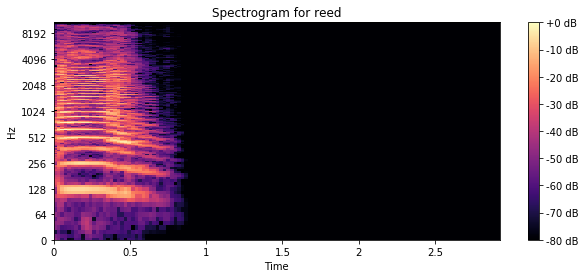

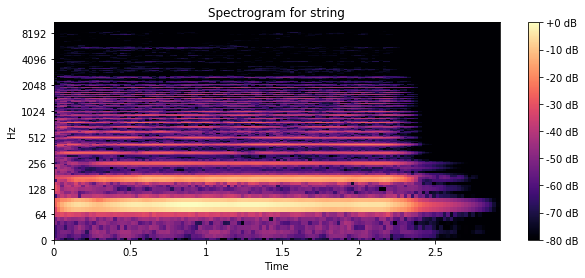

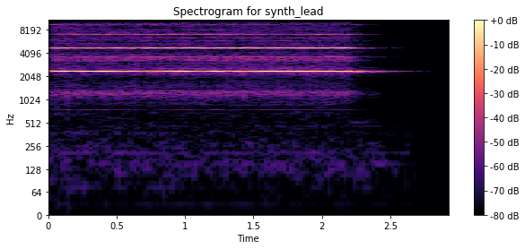

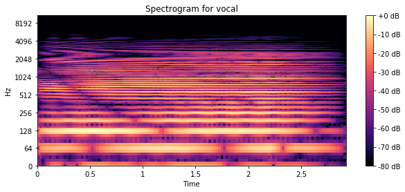

```python
spectrograms = []

for y_, sr_ in zip(y, sr):
    # Use left-aligned frames, instead of centered frames
    D = np.abs(librosa.stft(y_))
    spectro = librosa.amplitude_to_db(D, ref=np.max)
    spectrograms.append(spectro)

for S, instrument, i in zip(spectrograms,class_names, range(len(class_names))):
    plt.figure(figsize=(10,4))
    librosa.display.specshow(S,
                         y_axis='log', fmax=8000, x_axis='time')
    plt.colorbar(format='%+2.0f dB')
    plt.title("Spectrogram for " + instrument)
    plt.savefig('plots/spectro_'+str(class_names[i])+'.png')

plt.show()
```

### Mel-Frequency Cepstral Coefficients: [librosa.feature.mfcc](https://librosa.github.io/librosa/generated/librosa.feature.mfcc.html)

The **mel-frequency cepstrum (MFC)** is a presentation of the short term power spectrum of a sound, based on a linear cosine transform of a log power spectrum on a nonlinear mel scale of frequency. MFC coefficients are the coefficients that make up an MFC. Using a mel scale means that the bands are equally scaled, which resembles the human hearing system more than linearly spaced based bands in a normal spectrum.

MFCCs are commonly derived as follows:

1) Take the Fourier transform of (a windowed excerpt of) a signal.  
2) Map the powers of the spectrum obtained above onto the mel scale, using triangular overlapping windows.  
3) Take the logs of the powers at each of the mel frequencies.  
4) Take the discrete cosine transform of the list of mel log powers, as if it were a signal.  
5) The MFCCs are the amplitudes of the resulting spectrum.

Sources:  
[Speech Processing for Machine Learning](https://haythamfayek.com/2016/04/21/speech-processing-for-machine-learning.html)  
[Wikipedia: Mel Frequency Cepstrum](https://en.wikipedia.org/wiki/Mel-frequency_cepstrum)  
[Mel Frequency Cepstral Coefficient (MFCC) tutorial](http://practicalcryptography.com/miscellaneous/machine-learning/guide-mel-frequency-cepstral-coefficients-mfccs/#why-do-we-do-these-things)

```python
mfccs = []
for y_, sr_ in zip(y, sr):
    mfccs.append(librosa.feature.mfcc(y=y_, sr=sr_, n_mfcc=13))
```

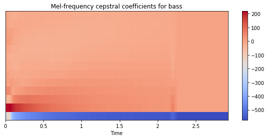

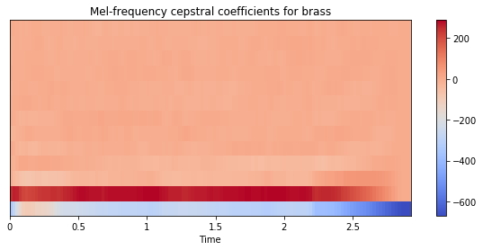

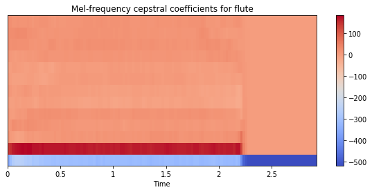

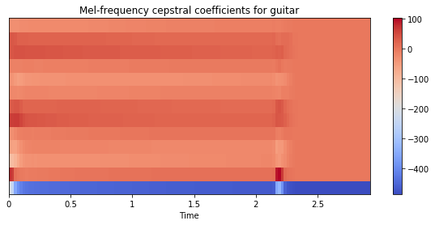

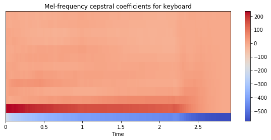

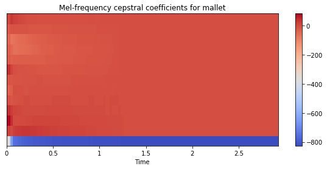

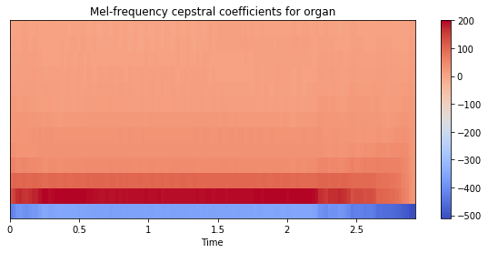

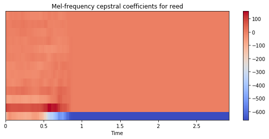

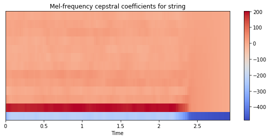

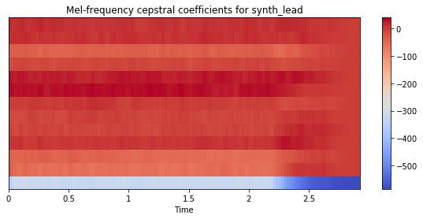

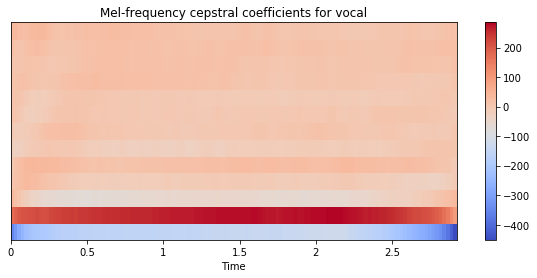

```python
for mfcc, instrument,i in zip(mfccs,class_names,range(len(class_names))):
    plt.figure(figsize=(10,4))
    librosa.display.specshow(mfcc, x_axis='time')
    plt.colorbar()
    plt.title('Mel-frequency cepstral coefficients for ' + instrument)
    plt.savefig('plots/mfcc'+str(class_names[i])+'.png')
plt.show()
```

### Spectral Centroid: [librosa.feature.spectral_centroid](https://librosa.github.io/librosa/generated/librosa.feature.spectral_centroid.html)

The **spectral centroid** is commonly associated with the measure of the brightness of a sound. This measure is obtained by evaluating the “center of gravity” using the Fourier transform’s frequency and magnitude information. The individual centroid of a spectral frame is defined as the average frequency weighted by amplitudes, divided by the sum of the amplitudes.

Source:  
[Spectral Centroid](https://www.cs.cmu.edu/~music/icm/slides/05-algorithmic-composition.pdf)

```python
centroids = []
spectrograms = []
phases = []

for y_, sr_ in zip(y, sr):
    centroids.append(librosa.feature.spectral_centroid(y=y_, sr=sr_))
    spectrograms.append(librosa.magphase(librosa.stft(y=y_))[0])
    phases.append(librosa.magphase(librosa.stft(y=y_))[1])
```

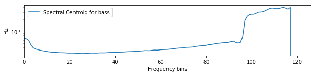

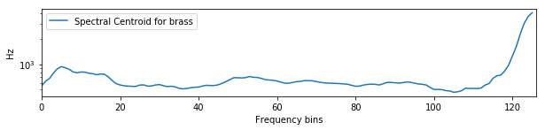

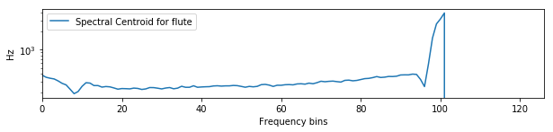

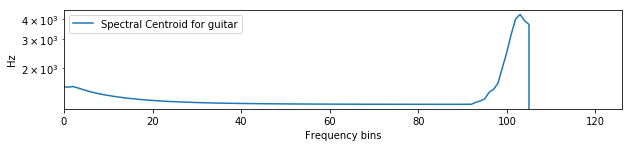

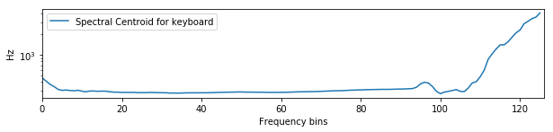

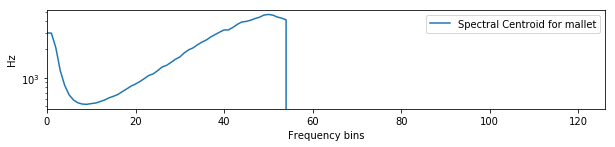

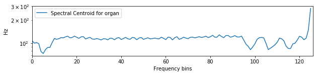

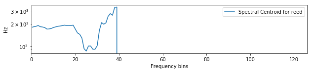

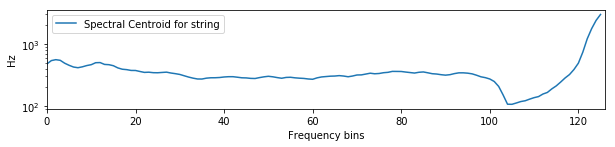

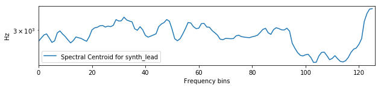

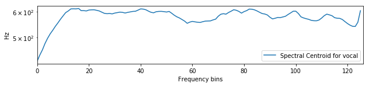

```python
#Make a plot with log scaling on the y axis.
for C, instrument, S, i in zip(centroids ,class_names, spectrograms, range(len(class_names))):
    plt.figure(figsize=(10,4))
    plt.subplot(2, 1, 1)
    plt.semilogy(C.T, label='Spectral Centroid for ' + instrument)
    plt.ylabel('Hz')
    plt.xticks(np.arange(0,C.shape[-1],20))
    plt.xlim([0, C.shape[-1]])
    plt.xlabel('Frequency bins')
    plt.legend()
    #plt.subplot(2, 1, 2)
    #librosa.display.specshow(librosa.amplitude_to_db(S, ref=np.max),y_axis='log', x_axis='time')
    #plt.title('log Power spectrogram for ' + instrument)
    #plt.tight_layout()
    plt.savefig('plots/spectral_centroid'+str(class_names[i])+'.png')

plt.show()
```

### Spectral Contrast: [librosa.feature.spectral_contrast](https://librosa.github.io/librosa/generated/librosa.feature.spectral_contrast.html)

**Spectral contrast** is defined as the level difference between peaks and valleys in the spectrum. Octave-based Spectral Contrast considers the spectral peak, spectral valley and their difference in each sub-band.  
Source:  
[Jiang, Dan-Ning, Lie Lu, Hong-Jiang Zhang, Jian-Hua Tao, and Lian-Hong Cai. “Music type classification by spectral contrast feature.” In Multimedia and Expo, 2002. ICME‘02. Proceedings. 2002 IEEE International Conference on, vol. 1, pp. 113-116. IEEE, 2002.](http://citeseerx.ist.psu.edu/viewdoc/download?doi=10.1.1.583.7201&rep=rep1&type=pdf)

```python
contrasts = []
for y_, sr_ in zip(y, sr):
    contrasts.append(librosa.feature.spectral_contrast(y=y_, sr=sr_))
```

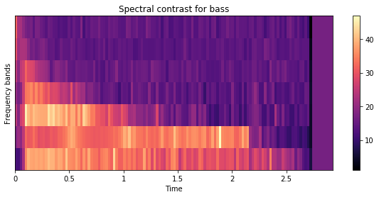

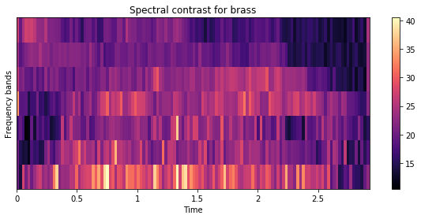

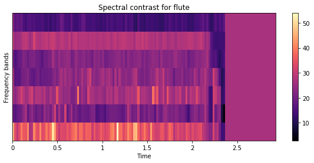

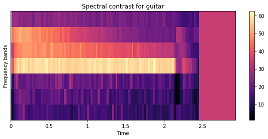

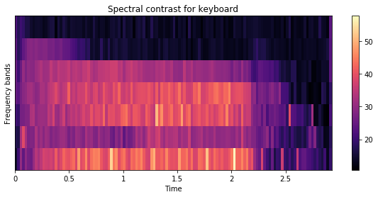

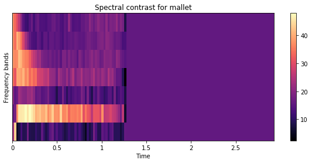

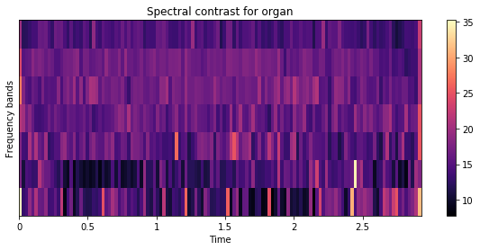

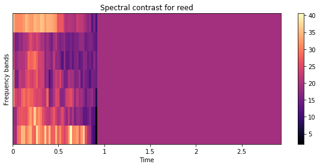

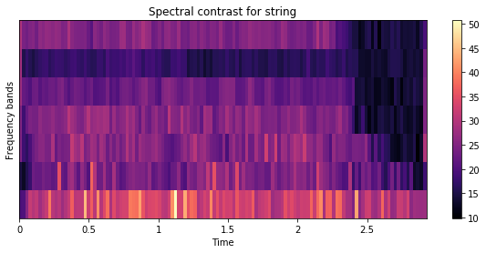

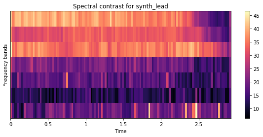

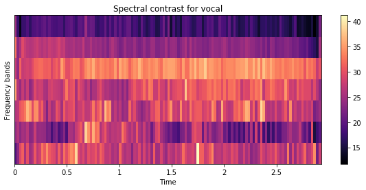

```python
for contrast, instrument, i in zip(contrasts,class_names, range(len(class_names))):
    plt.figure(figsize=(10,4))
    librosa.display.specshow(contrast,x_axis='time')
    plt.colorbar()
    plt.ylabel('Frequency bands')
    plt.title('Spectral contrast for '+ instrument)
    plt.savefig('plots/spectral_contrast_'+str(class_names[i])+'.png')

plt.show()
```